# HW4

### MAE GAP Plot:

#### Conclusion

This analysis shows that a model trained on one region doesn’t always perform equally well on other regions. While it generalizes fairly well to Region_4 and Region_5, the performance drops significantly in Region_1. This suggests that the **relationship between GC content and coverage may vary across the chromosome**, and in some cases, it might be better to **fit region-specific models** rather than assume a single function fits all areas.

### Localized Modeling Approach

In this section, we explore whether the relationship between **GC content** and **sequencing coverage** is consistent throughout the chromosome or varies across regions.  
Unlike the previous method, where a model was trained on **Region 2** and evaluated on the other regions, here we apply a **localized approach**:  
We split the chromosome into **five distinct regions**, and within **each region**, we perform a separate **train/test split** and fit an **independent spline model**.

This method helps assess whether it’s more appropriate to use a **single global model** or to model **each region individually**, allowing us to capture potential **local variability** in the GC-coverage relationship.

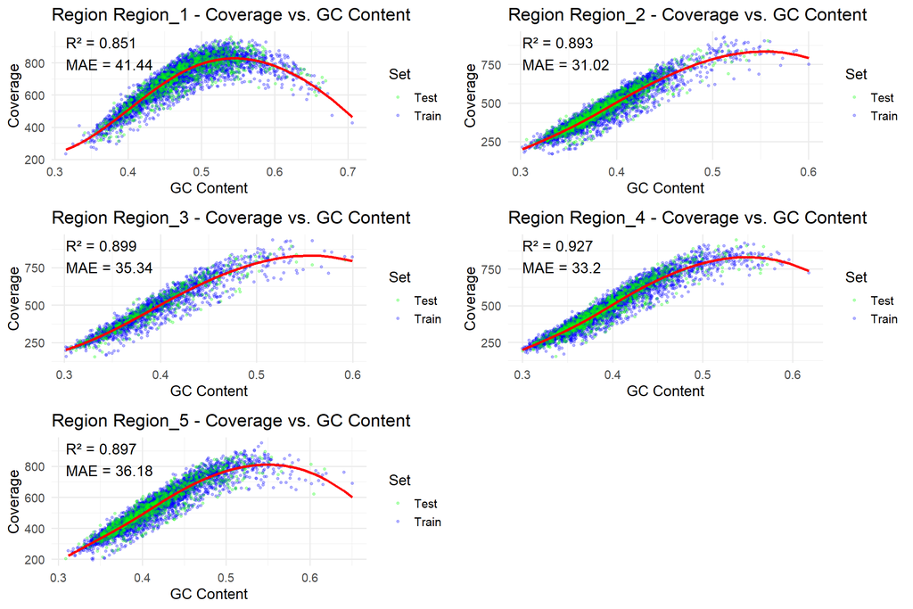

```r
library(ggplot2)
library(splines)
library(caret)
library(gridExtra)

set.seed(123)
plots <- list()

# Loop over regions
for (r in sort(unique(df_clean$Region))) {

  # Subset data for region
  region_data <- df_clean %>% filter(Region == r)

  # Train/test split
  train_index <- createDataPartition(region_data$Coverage, p = 0.8, list = FALSE)
  train_data <- region_data[train_index, ]
  test_data  <- region_data[-train_index, ]

  # Fit spline model on train
  model <- lm(Coverage ~ bs(GC_Content, df = 5), data = train_data)

  # Predictions
  train_data$Predicted <- predict(model, newdata = train_data)
  test_data$Predicted <- predict(model, newdata = test_data)

  # MAE and R²
  mae_test <- round(mean(abs(test_data$Coverage - test_data$Predicted)), 2)
  r2_test <- round(summary(model)$r.squared, 3)

  # Combine data
  train_data$Set <- "Train"
  test_data$Set <- "Test"
  region_combined <- rbind(train_data, test_data)

  # Plot
  p <- ggplot(region_combined, aes(x = GC_Content, y = Coverage, color = Set)) +
    geom_point(alpha = 0.3, size = 1) +
    geom_line(data = train_data, aes(x = GC_Content, y = Predicted), color = "red", size = 1.2) +
    scale_color_manual(values = c("Train" = "blue", "Test" = "green")) +
    labs(
      title = paste("Region", r, "- Coverage vs. GC Content"),
      x = "GC Content",
      y = "Coverage",
      color = "Set"
    ) +
    annotate("text", x = min(region_data$GC_Content, na.rm = TRUE), y = max(region_data$Coverage, na.rm = TRUE),
             label = paste0("R² = ", r2_test, "\nMAE = ", mae_test),
             hjust = 0, vjust = 1, size = 5) +
    theme_minimal(base_size = 14)

  plots[[r]] <- p
}

# Display all plots
do.call(grid.arrange, c(plots, ncol = 2))
```

### Interpretation of Results

The plots show that the relationship between **GC content** and **coverage** tends to follow a **curved, non-linear pattern** in all regions — usually rising with GC content and then tapering off.

These results indicate that the GC-coverage relationship is **not completely consistent** across the chromosome.  
Some regions show **stronger and clearer patterns**, while others are more **noisy or irregular**.

This supports the idea that **fitting a separate model for each region** can better capture local trends and reduce prediction errors, rather than assuming a single model fits the entire chromosome.

### Part D: Exploring the Optimal Bin Size for Modeling the GC-Coverage Relationship

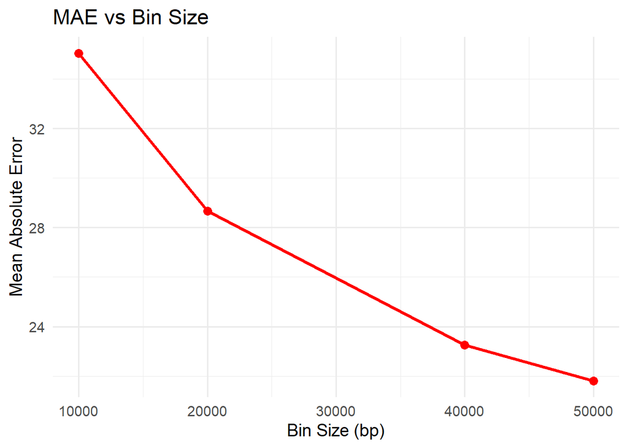

```r
# Define bin sizes to test — all must be multiples of 10,000 (the resolution of df_clean)
bin_sizes <- c(10000, 20000, 40000, 50000)

# Create an empty dataframe to store model predictions for all bin sizes
all_model_data <- data.frame()

# Loop through each bin size and fit a spline model
for (size in bin_sizes) {

  bin_ratio <- size / 10000  # Assuming df_clean is based on 10,000bp bins

  # Aggregate the original bins to match the desired bin size
  df_agg <- df_clean %>%
    mutate(Aggregated_Bin = floor((Bin - 1) / bin_ratio) + 1) %>%
    group_by(Aggregated_Bin) %>%
    summarise(
      Coverage = mean(Coverage),
      GC_Content = mean(GC_Content),
      .groups = "drop"
    ) %>%
    filter(Coverage > 0, GC_Content >= 0.2, GC_Content <= 0.7)

  # Fit a cubic spline regression model
  model <- lm(Coverage ~ bs(GC_Content, df = 5), data = df_agg)

  # Add predictions and bin size as columns
  df_agg$Predicted <- predict(model, newdata = df_agg)
  df_agg$Bin_Size <- size

  # Combine into full dataset for visualization
  all_model_data <- rbind(all_model_data, df_agg)
}
# Load required libraries
library(dplyr)
library(ggplot2)
library(splines)

# Initialize results table
results <- data.frame(
  Bin_Size = integer(),
  R2 = numeric(),
  MAE = numeric()
)

# Loop over bin sizes
for (size in bin_sizes) {

  bin_ratio <- size / 10000  # original bins are 10,000 bp

  # Aggregate bins from df_clean using bin_ratio
  df_agg <- df_clean %>%
    mutate(Aggregated_Bin = floor((Bin - 1) / bin_ratio) + 1) %>%
    group_by(Aggregated_Bin) %>%
    summarise(
      Coverage = mean(Coverage),
      GC_Content = mean(GC_Content),
      .groups = "drop"
    ) %>%
    filter(Coverage > 0, GC_Content >= 0.2, GC_Content <= 0.7)

  # Fit spline model on aggregated data
  model <- lm(Coverage ~ bs(GC_Content, df = 5), data = df_agg)
  predictions <- predict(model, newdata = df_agg)

  # Evaluate model
  r2 <- round(summary(model)$r.squared, 4)
  mae <- round(mean(abs(df_agg$Coverage - predictions)), 2)

  results <- rbind(results, data.frame(
    Bin_Size = size,
    R2 = r2,
    MAE = mae
  ))
}

# Plot MAE vs Bin Size
ggplot(results, aes(x = Bin_Size, y = MAE)) +
  geom_line(color = "red", size = 1.2) +
  geom_point(size = 3, color = "red") +
  labs(
    title = "MAE vs Bin Size",
    x = "Bin Size (bp)",
    y = "Mean Absolute Error"
  ) +
  theme_minimal(base_size = 14)
```

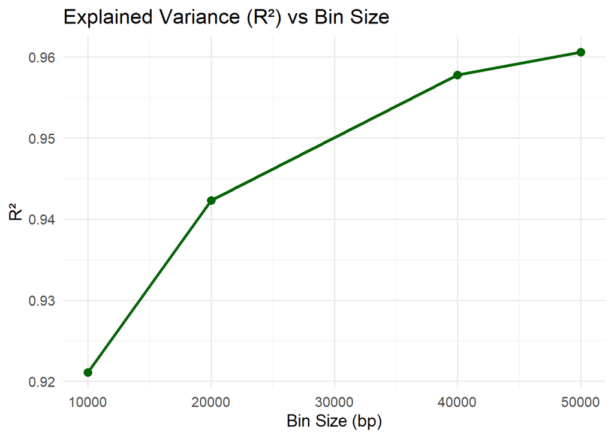

```r
# Plot R² vs Bin Size
ggplot(results, aes(x = Bin_Size, y = R2)) +
  geom_line(color = "darkgreen", size = 1.2) +
  geom_point(size = 3, color = "darkgreen") +
  labs(
    title = "Explained Variance (R²) vs Bin Size",
    x = "Bin Size (bp)",
    y = "R²"
  ) +
  theme_minimal(base_size = 14)
```

```r
library(ggplot2)
library(dplyr)

# Add annotation labels for R² and MAE per bin size
label_data <- all_model_data %>%
  group_by(Bin_Size) %>%
  summarise(
    R2 = round(cor(Coverage, Predicted)^2, 3),
    MAE = round(mean(abs(Coverage - Predicted)), 2),
    x = max(GC_Content, na.rm = TRUE),
    y = max(Coverage, na.rm = TRUE)
  ) %>%
  mutate(label = paste0("R² = ", R2, "\nMAE = ", MAE))


# View the summarized results table
print(results)
```

```
##   Bin_Size     R2   MAE
## 1    10000 0.9211 35.04
## 2    20000 0.9423 28.67
## 3    40000 0.9578 23.26
## 4    50000 0.9606 21.81
```

### Analysis Summary – Effect of Bin Size on GC-Coverage Relationship

In this analysis, we investigated how the relationship between GC content and sequencing coverage varies with different bin sizes (10,000 to 50,000 bp). For each bin size, we aggregated the cleaned data, fitted a cubic spline regression model, and computed two key metrics:  
- **R² (explained variance)**: how much of the variation in coverage is explained by GC content.  
- **MAE (mean absolute error)**: the average prediction error of the model.

The results clearly indicate that **as bin size increases, both model accuracy and explanatory power improve**: - The **MAE consistently decreases**, dropping from **35.04** at 10kb to **21.81** at 50kb.  
- The **R² steadily increases**, from **0.9211** to **0.9606**, indicating a stronger and more stable association between GC content and coverage in larger bins.

This behavior makes intuitive sense: larger bins reduce local noise and reveal broader patterns, allowing the GC-coverage relationship to emerge more clearly. In contrast, smaller bins are more susceptible to variability from local artifacts, which weakens the signal.

**Conclusion**: The GC-coverage relationship becomes stronger and more predictive at larger bin sizes. For robust modeling and normalization, bins of **40,000–50,000 bp** yield the most consistent results.

### Visualizing GC-Coverage Patterns Across Bin Sizes

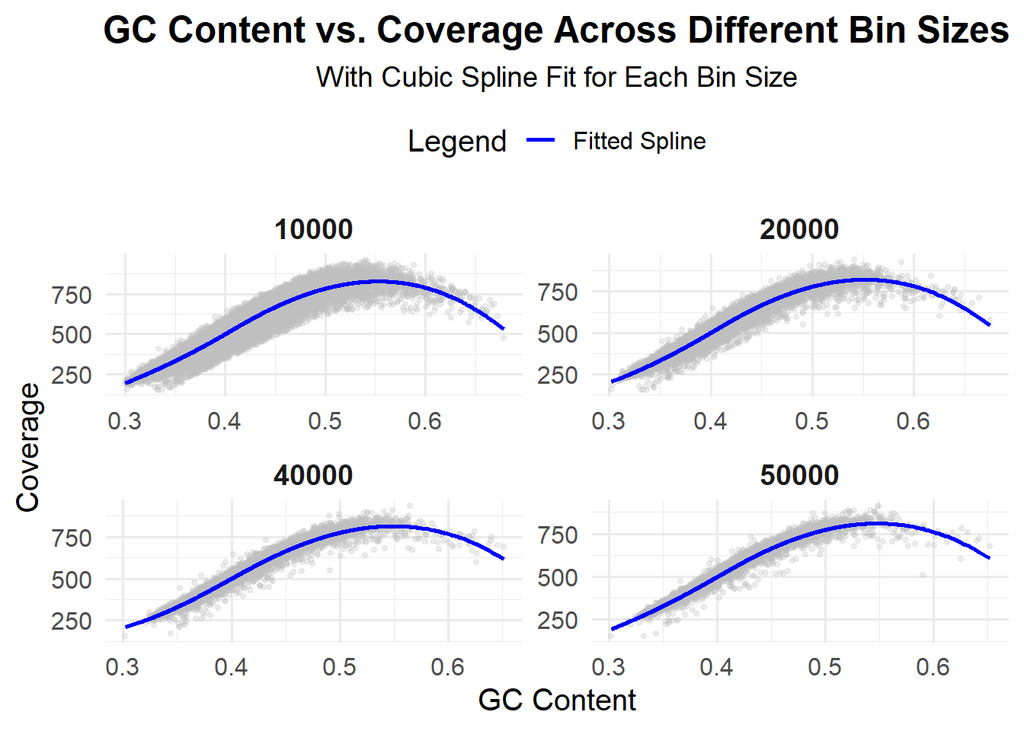

```r
# Plot: GC Content vs Coverage with spline prediction by bin size
ggplot(all_model_data, aes(x = GC_Content, y = Coverage)) +

  # Add the original coverage points as light gray dots
  geom_point(alpha = 0.3, color = "gray", size = 1) +

  # Add the spline prediction line in blue with a legend label
  geom_line(aes(y = Predicted, color = "Fitted Spline"), size = 1) +

  # Create separate panels for each bin size, arranged in two columns
  facet_wrap(~ Bin_Size, scales = "free", ncol = 2) +

  # Define plot titles and axis labels
  labs(
    title = "GC Content vs. Coverage Across Different Bin Sizes",
    subtitle = "With Cubic Spline Fit for Each Bin Size",
    x = "GC Content",
    y = "Coverage",
    color = "Legend"
  ) +

  # Define manual color for the fitted line
  scale_color_manual(values = c("Fitted Spline" = "blue")) +

  # Apply a minimal theme for clean appearance
  theme_minimal(base_size = 15) +

  # Customize the theme: move legend to top, bold facet titles and plot titles
  theme(
    legend.position = "top",
    strip.text = element_text(size = 14, face = "bold"),
    plot.title = element_text(face = "bold", size = 18, hjust = 0.5),
    plot.subtitle = element_text(size = 14, hjust = 0.5)
  )
```

### Visual Interpretation of Spline Fits

The plots confirm what we saw in the numeric results: **larger bins produce smoother and more stable fits**, with less noise and clearer trends.  
This supports the conclusion that **larger bin sizes (like 40,000 or 50,000 bp)** better capture the underlying GC bias in sequencing coverage.

### Lab Summary – Modeling GC Bias in Sequencing Coverage

In this lab, we explored how GC content affects sequencing coverage across chromosome 1. We started by cleaning the data to remove extreme outliers, using residuals from a LOESS fit to capture and exclude unusual coverage patterns. Then, we used spline regression models to study the non-linear relationship between GC content and coverage, both within single regions and across different parts of the chromosome. We also tested whether G and C separately explain coverage as well as their combined effect.

Finally, we analyzed how different bin sizes impact the clarity and stability of the GC-coverage relationship, comparing model performance at several resolutions. Throughout the lab, we used both visualizations and numeric metrics like R² and MAE to compare models and evaluate their accuracy.

**One thing We’ve learned**: The size of the genomic bins we use can make a big difference — larger bins reduce noise and help reveal clearer patterns in the data.